# League of Legends Project

Group 9 - Ziyue Chen, Rishabh Kaushik, Vera Meanti, Aman Sharma, Sarah Wu, Stephen Zhu

1. A statement of the question or purpose. What problems or questions did you set out to analyse? What were the key issues raised?

League of Legends is a Multiplayer Online Battle Arena (MOBA) game. For this project we have data on the first 10 minutes of 10,000 games. All of these games are diamond-ranked, which means the players are in the top 1.5% to 0.19% of players worldwide. The game lasts approximately 20 to 30 mins, there are two teams (Red vs Blue), with 5 players each. The goal of the game is to take down the enemy Nexus.

Our purpose is to explore what is the best strategy in the first 10mins of playing, to win League of Legends.

2. The background and preparation for conducting the project. How did you prepare for the project? What sources or background readings did you consult? What information did you use in developing your ideas from the conceptual stage to the finished project?

As not all of us were familiar with the League of Legends game, we had to conduct some research to really understand the game and the variables in the dataset. All our group members played the game to immerse ourselves in the League of Legends world and understand what stories could be told from the data.

3. Methodology. What did you do, and how did you do it? What statistical techniques did you use — for instance, scatterplots, correlation, confidence intervals, linear/logistic regression?
4. Results and conclusions. This is where you summarise and present your data analyses and communicate your main results. What did you find out? This might include tables, graphs, or verbal summaries. What did you learn about the problem or question you set out to investigate?
5. Discussion and critique. What did you learn about the process of carrying out your project? What went wrong, and how could you improve it next time? For instance, did any sources of bias creep into your survey or experiment? What advice would you give future students?

## Loading the Dataset

```r
#Loading the dataset
raw_lol_data <- read.csv("high_diamond_ranked_10min.csv")

#Initial cleaning of names and dropping any na's
raw_lol_data <- raw_lol_data %>%
  janitor::clean_names() %>%
  drop_na()
```

# Cleaning the Data

```r
# Checking that variables are all stored as the right type
glimpse(raw_lol_data)
```

```
## Rows: 9,879
## Columns: 40
## $ game_id                          <dbl> 4519157822, 4523371949, 4521474530, 4~
## $ blue_wins                        <int> 0, 0, 0, 0, 0, 1, 1, 0, 0, 1, 0, 0, 1~
## $ blue_wards_placed                <int> 28, 12, 15, 43, 75, 18, 18, 16, 16, 1~
## $ blue_wards_destroyed             <int> 2, 1, 0, 1, 4, 0, 3, 2, 3, 1, 3, 2, 1~
## $ blue_first_blood                 <int> 1, 0, 0, 0, 0, 0, 1, 0, 0, 1, 1, 1, 1~
## $ blue_kills                       <int> 9, 5, 7, 4, 6, 5, 7, 5, 7, 4, 4, 11, ~
## $ blue_deaths                      <int> 6, 5, 11, 5, 6, 3, 6, 13, 7, 5, 4, 11~
## $ blue_assists                     <int> 11, 5, 4, 5, 6, 6, 7, 3, 8, 5, 6, 7, ~
## $ blue_elite_monsters              <int> 0, 0, 1, 1, 0, 1, 1, 0, 0, 1, 0, 1, 1~
## $ blue_dragons                     <int> 0, 0, 1, 0, 0, 1, 1, 0, 0, 1, 0, 0, 1~
## $ blue_heralds                     <int> 0, 0, 0, 1, 0, 0, 0, 0, 0, 0, 0, 1, 0~
## $ blue_towers_destroyed            <int> 0, 0, 0, 0, 0, 0, 0, 0, 0, 0, 0, 0, 0~
## $ blue_total_gold                  <int> 17210, 14712, 16113, 15157, 16400, 15~
```

[output cut: 27 more lines]

```r
#Skimming Data to check that there are no missing values
skimr::skim(raw_lol_data)
```

Data summary

| Name | raw_lol_data |
| --- | --- |
| Number of rows | 9879 |
| Number of columns | 40 |
| _______________________ |  |
| Column type frequency: |  |
| numeric | 40 |
| ________________________ |  |
| Group variables | None |

**Variable type: numeric**

| skim_variable | n_missing | complete_rate | mean | sd | p0 | p25 | p50 | p75 | p100 | hist |
| --- | --- | --- | --- | --- | --- | --- | --- | --- | --- | --- |
| game_id | 0 | 1 | 4500084044.85 | 27573278.49 | 4295358071.0 | 4483301169.00 | 4510920346.0 | 4.521733e+09 | 4527990640.0 | ▁▁▁▂▇ |
| blue_wins | 0 | 1 | 0.50 | 0.50 | 0.0 | 0.00 | 0.0 | 1.000000e+00 | 1.0 | ▇▁▁▁▇ |
| blue_wards_placed | 0 | 1 | 22.29 | 18.02 | 5.0 | 14.00 | 16.0 | 2.000000e+01 | 250.0 | ▇▁▁▁▁ |
| blue_wards_destroyed | 0 | 1 | 2.82 | 2.17 | 0.0 | 1.00 | 3.0 | 4.000000e+00 | 27.0 | ▇▁▁▁▁ |
| blue_first_blood | 0 | 1 | 0.50 | 0.50 | 0.0 | 0.00 | 1.0 | 1.000000e+00 | 1.0 | ▇▁▁▁▇ |
| blue_kills | 0 | 1 | 6.18 | 3.01 | 0.0 | 4.00 | 6.0 | 8.000000e+00 | 22.0 | ▅▇▃▁▁ |
| blue_deaths | 0 | 1 | 6.14 | 2.93 | 0.0 | 4.00 | 6.0 | 8.000000e+00 | 22.0 | ▅▇▃▁▁ |
| blue_assists | 0 | 1 | 6.65 | 4.06 | 0.0 | 4.00 | 6.0 | 9.000000e+00 | 29.0 | ▇▇▂▁▁ |
| blue_elite_monsters | 0 | 1 | 0.55 | 0.63 | 0.0 | 0.00 | 0.0 | 1.000000e+00 | 2.0 | ▇▁▆▁▁ |
| blue_dragons | 0 | 1 | 0.36 | 0.48 | 0.0 | 0.00 | 0.0 | 1.000000e+00 | 1.0 | ▇▁▁▁▅ |
| blue_heralds | 0 | 1 | 0.19 | 0.39 | 0.0 | 0.00 | 0.0 | 0.000000e+00 | 1.0 | ▇▁▁▁▂ |
| blue_towers_destroyed | 0 | 1 | 0.05 | 0.24 | 0.0 | 0.00 | 0.0 | 0.000000e+00 | 4.0 | ▇▁▁▁▁ |
| blue_total_gold | 0 | 1 | 16503.46 | 1535.45 | 10730.0 | 15415.50 | 16398.0 | 1.745900e+04 | 23701.0 | ▁▆▇▂▁ |
| blue_avg_level | 0 | 1 | 6.92 | 0.31 | 4.6 | 6.80 | 7.0 | 7.200000e+00 | 8.0 | ▁▁▂▇▁ |
| blue_total_experience | 0 | 1 | 17928.11 | 1200.52 | 10098.0 | 17168.00 | 17951.0 | 1.872400e+04 | 22224.0 | ▁▁▃▇▁ |
| blue_total_minions_killed | 0 | 1 | 216.70 | 21.86 | 90.0 | 202.00 | 218.0 | 2.320000e+02 | 283.0 | ▁▁▃▇▁ |
| blue_total_jungle_minions_killed | 0 | 1 | 50.51 | 9.90 | 0.0 | 44.00 | 50.0 | 5.600000e+01 | 92.0 | ▁▁▇▃▁ |
| blue_gold_diff | 0 | 1 | 14.41 | 2453.35 | -10830.0 | -1585.50 | 14.0 | 1.596000e+03 | 11467.0 | ▁▂▇▂▁ |
| blue_experience_diff | 0 | 1 | -33.62 | 1920.37 | -9333.0 | -1290.50 | -28.0 | 1.212000e+03 | 8348.0 | ▁▂▇▃▁ |
| blue_cs_per_min | 0 | 1 | 21.67 | 2.19 | 9.0 | 20.20 | 21.8 | 2.320000e+01 | 28.3 | ▁▁▃▇▁ |
| blue_gold_per_min | 0 | 1 | 1650.35 | 153.54 | 1073.0 | 1541.55 | 1639.8 | 1.745900e+03 | 2370.1 | ▁▆▇▂▁ |
| red_wards_placed | 0 | 1 | 22.37 | 18.46 | 6.0 | 14.00 | 16.0 | 2.000000e+01 | 276.0 | ▇▁▁▁▁ |
| red_wards_destroyed | 0 | 1 | 2.72 | 2.14 | 0.0 | 1.00 | 2.0 | 4.000000e+00 | 24.0 | ▇▁▁▁▁ |
| red_first_blood | 0 | 1 | 0.50 | 0.50 | 0.0 | 0.00 | 0.0 | 1.000000e+00 | 1.0 | ▇▁▁▁▇ |
| red_kills | 0 | 1 | 6.14 | 2.93 | 0.0 | 4.00 | 6.0 | 8.000000e+00 | 22.0 | ▅▇▃▁▁ |
| red_deaths | 0 | 1 | 6.18 | 3.01 | 0.0 | 4.00 | 6.0 | 8.000000e+00 | 22.0 | ▅▇▃▁▁ |
| red_assists | 0 | 1 | 6.66 | 4.06 | 0.0 | 4.00 | 6.0 | 9.000000e+00 | 28.0 | ▇▇▂▁▁ |
| red_elite_monsters | 0 | 1 | 0.57 | 0.63 | 0.0 | 0.00 | 0.0 | 1.000000e+00 | 2.0 | ▇▁▇▁▁ |
| red_dragons | 0 | 1 | 0.41 | 0.49 | 0.0 | 0.00 | 0.0 | 1.000000e+00 | 1.0 | ▇▁▁▁▆ |
| red_heralds | 0 | 1 | 0.16 | 0.37 | 0.0 | 0.00 | 0.0 | 0.000000e+00 | 1.0 | ▇▁▁▁▂ |
| red_towers_destroyed | 0 | 1 | 0.04 | 0.22 | 0.0 | 0.00 | 0.0 | 0.000000e+00 | 2.0 | ▇▁▁▁▁ |
| red_total_gold | 0 | 1 | 16489.04 | 1490.89 | 11212.0 | 15427.50 | 16378.0 | 1.741850e+04 | 22732.0 | ▁▅▇▂▁ |
| red_avg_level | 0 | 1 | 6.93 | 0.31 | 4.8 | 6.80 | 7.0 | 7.200000e+00 | 8.2 | ▁▁▇▇▁ |
| red_total_experience | 0 | 1 | 17961.73 | 1198.58 | 10465.0 | 17209.50 | 17974.0 | 1.876450e+04 | 22269.0 | ▁▁▅▇▁ |
| red_total_minions_killed | 0 | 1 | 217.35 | 21.91 | 107.0 | 203.00 | 218.0 | 2.330000e+02 | 289.0 | ▁▁▇▇▁ |
| red_total_jungle_minions_killed | 0 | 1 | 51.31 | 10.03 | 4.0 | 44.00 | 51.0 | 5.700000e+01 | 92.0 | ▁▁▇▃▁ |
| red_gold_diff | 0 | 1 | -14.41 | 2453.35 | -11467.0 | -1596.00 | -14.0 | 1.585500e+03 | 10830.0 | ▁▂▇▂▁ |
| red_experience_diff | 0 | 1 | 33.62 | 1920.37 | -8348.0 | -1212.00 | 28.0 | 1.290500e+03 | 9333.0 | ▁▃▇▂▁ |
| red_cs_per_min | 0 | 1 | 21.73 | 2.19 | 10.7 | 20.30 | 21.8 | 2.330000e+01 | 28.9 | ▁▁▇▇▁ |
| red_gold_per_min | 0 | 1 | 1648.90 | 149.09 | 1121.2 | 1542.75 | 1637.8 | 1.741850e+03 | 2273.2 | ▁▅▇▂▁ |

```r
#Checking for duplicates in the dataset
dupes <- raw_lol_data %>%
  janitor::get_dupes()
```

```
## No variable names specified - using all columns.
```

```
## No duplicate combinations found of: game_id, blue_wins, blue_wards_placed, blue_wards_destroyed, blue_first_blood, blue_kills, blue_deaths, blue_assists, blue_elite_monsters, ... and 31 other variables
```

```r
#Cleaning the data
clean_lol_data <- raw_lol_data %>%
  # There are duplicate columns between the blue and the red variables, so we decided to drop the red and keep the blue
  select(-red_first_blood, -red_gold_diff) %>%
  # We added a column that shows the average level difference between the blue and the red teams
  mutate(avg_level_diff = blue_avg_level - red_avg_level) %>%
  # Changing two variables to be discrete instead of continuous
  mutate(blue_wins = as.factor(blue_wins)) %>%
  mutate(blue_first_blood = as.factor(blue_first_blood)) %>%
  mutate(blue_KDA = (blue_kills + blue_assists)/blue_deaths, red_KDA = (red_kills + red_assists)/red_deaths)

# Making sure the clean data is correct
skimr::skim(clean_lol_data)
```

Data summary

| Name | clean_lol_data |
| --- | --- |
| Number of rows | 9879 |
| Number of columns | 41 |
| _______________________ |  |
| Column type frequency: |  |
| factor | 2 |
| numeric | 39 |
| ________________________ |  |
| Group variables | None |

**Variable type: factor**

| skim_variable | n_missing | complete_rate | ordered | n_unique | top_counts |
| --- | --- | --- | --- | --- | --- |
| blue_wins | 0 | 1 | FALSE | 2 | 0: 4949, 1: 4930 |
| blue_first_blood | 0 | 1 | FALSE | 2 | 1: 4987, 0: 4892 |

**Variable type: numeric**

| skim_variable | n_missing | complete_rate | mean | sd | p0 | p25 | p50 | p75 | p100 | hist |
| --- | --- | --- | --- | --- | --- | --- | --- | --- | --- | --- |
| game_id | 0 | 1 | 4500084044.85 | 27573278.49 | 4295358071.0 | 4483301169.00 | 4510920346.0 | 4.521733e+09 | 4527990640.0 | ▁▁▁▂▇ |
| blue_wards_placed | 0 | 1 | 22.29 | 18.02 | 5.0 | 14.00 | 16.0 | 2.000000e+01 | 250.0 | ▇▁▁▁▁ |
| blue_wards_destroyed | 0 | 1 | 2.82 | 2.17 | 0.0 | 1.00 | 3.0 | 4.000000e+00 | 27.0 | ▇▁▁▁▁ |
| blue_kills | 0 | 1 | 6.18 | 3.01 | 0.0 | 4.00 | 6.0 | 8.000000e+00 | 22.0 | ▅▇▃▁▁ |
| blue_deaths | 0 | 1 | 6.14 | 2.93 | 0.0 | 4.00 | 6.0 | 8.000000e+00 | 22.0 | ▅▇▃▁▁ |
| blue_assists | 0 | 1 | 6.65 | 4.06 | 0.0 | 4.00 | 6.0 | 9.000000e+00 | 29.0 | ▇▇▂▁▁ |
| blue_elite_monsters | 0 | 1 | 0.55 | 0.63 | 0.0 | 0.00 | 0.0 | 1.000000e+00 | 2.0 | ▇▁▆▁▁ |
| blue_dragons | 0 | 1 | 0.36 | 0.48 | 0.0 | 0.00 | 0.0 | 1.000000e+00 | 1.0 | ▇▁▁▁▅ |
| blue_heralds | 0 | 1 | 0.19 | 0.39 | 0.0 | 0.00 | 0.0 | 0.000000e+00 | 1.0 | ▇▁▁▁▂ |
| blue_towers_destroyed | 0 | 1 | 0.05 | 0.24 | 0.0 | 0.00 | 0.0 | 0.000000e+00 | 4.0 | ▇▁▁▁▁ |
| blue_total_gold | 0 | 1 | 16503.46 | 1535.45 | 10730.0 | 15415.50 | 16398.0 | 1.745900e+04 | 23701.0 | ▁▆▇▂▁ |
| blue_avg_level | 0 | 1 | 6.92 | 0.31 | 4.6 | 6.80 | 7.0 | 7.200000e+00 | 8.0 | ▁▁▂▇▁ |
| blue_total_experience | 0 | 1 | 17928.11 | 1200.52 | 10098.0 | 17168.00 | 17951.0 | 1.872400e+04 | 22224.0 | ▁▁▃▇▁ |
| blue_total_minions_killed | 0 | 1 | 216.70 | 21.86 | 90.0 | 202.00 | 218.0 | 2.320000e+02 | 283.0 | ▁▁▃▇▁ |
| blue_total_jungle_minions_killed | 0 | 1 | 50.51 | 9.90 | 0.0 | 44.00 | 50.0 | 5.600000e+01 | 92.0 | ▁▁▇▃▁ |
| blue_gold_diff | 0 | 1 | 14.41 | 2453.35 | -10830.0 | -1585.50 | 14.0 | 1.596000e+03 | 11467.0 | ▁▂▇▂▁ |
| blue_experience_diff | 0 | 1 | -33.62 | 1920.37 | -9333.0 | -1290.50 | -28.0 | 1.212000e+03 | 8348.0 | ▁▂▇▃▁ |
| blue_cs_per_min | 0 | 1 | 21.67 | 2.19 | 9.0 | 20.20 | 21.8 | 2.320000e+01 | 28.3 | ▁▁▃▇▁ |
| blue_gold_per_min | 0 | 1 | 1650.35 | 153.54 | 1073.0 | 1541.55 | 1639.8 | 1.745900e+03 | 2370.1 | ▁▆▇▂▁ |
| red_wards_placed | 0 | 1 | 22.37 | 18.46 | 6.0 | 14.00 | 16.0 | 2.000000e+01 | 276.0 | ▇▁▁▁▁ |
| red_wards_destroyed | 0 | 1 | 2.72 | 2.14 | 0.0 | 1.00 | 2.0 | 4.000000e+00 | 24.0 | ▇▁▁▁▁ |
| red_kills | 0 | 1 | 6.14 | 2.93 | 0.0 | 4.00 | 6.0 | 8.000000e+00 | 22.0 | ▅▇▃▁▁ |
| red_deaths | 0 | 1 | 6.18 | 3.01 | 0.0 | 4.00 | 6.0 | 8.000000e+00 | 22.0 | ▅▇▃▁▁ |
| red_assists | 0 | 1 | 6.66 | 4.06 | 0.0 | 4.00 | 6.0 | 9.000000e+00 | 28.0 | ▇▇▂▁▁ |
| red_elite_monsters | 0 | 1 | 0.57 | 0.63 | 0.0 | 0.00 | 0.0 | 1.000000e+00 | 2.0 | ▇▁▇▁▁ |
| red_dragons | 0 | 1 | 0.41 | 0.49 | 0.0 | 0.00 | 0.0 | 1.000000e+00 | 1.0 | ▇▁▁▁▆ |
| red_heralds | 0 | 1 | 0.16 | 0.37 | 0.0 | 0.00 | 0.0 | 0.000000e+00 | 1.0 | ▇▁▁▁▂ |
| red_towers_destroyed | 0 | 1 | 0.04 | 0.22 | 0.0 | 0.00 | 0.0 | 0.000000e+00 | 2.0 | ▇▁▁▁▁ |
| red_total_gold | 0 | 1 | 16489.04 | 1490.89 | 11212.0 | 15427.50 | 16378.0 | 1.741850e+04 | 22732.0 | ▁▅▇▂▁ |
| red_avg_level | 0 | 1 | 6.93 | 0.31 | 4.8 | 6.80 | 7.0 | 7.200000e+00 | 8.2 | ▁▁▇▇▁ |
| red_total_experience | 0 | 1 | 17961.73 | 1198.58 | 10465.0 | 17209.50 | 17974.0 | 1.876450e+04 | 22269.0 | ▁▁▅▇▁ |
| red_total_minions_killed | 0 | 1 | 217.35 | 21.91 | 107.0 | 203.00 | 218.0 | 2.330000e+02 | 289.0 | ▁▁▇▇▁ |
| red_total_jungle_minions_killed | 0 | 1 | 51.31 | 10.03 | 4.0 | 44.00 | 51.0 | 5.700000e+01 | 92.0 | ▁▁▇▃▁ |
| red_experience_diff | 0 | 1 | 33.62 | 1920.37 | -8348.0 | -1212.00 | 28.0 | 1.290500e+03 | 9333.0 | ▁▃▇▂▁ |
| red_cs_per_min | 0 | 1 | 21.73 | 2.19 | 10.7 | 20.30 | 21.8 | 2.330000e+01 | 28.9 | ▁▁▇▇▁ |
| red_gold_per_min | 0 | 1 | 1648.90 | 149.09 | 1121.2 | 1542.75 | 1637.8 | 1.741850e+03 | 2273.2 | ▁▅▇▂▁ |
| avg_level_diff | 0 | 1 | -0.01 | 0.48 | -2.6 | -0.40 | 0.0 | 2.000000e-01 | 2.4 | ▁▁▇▂▁ |
| blue_KDA | 0 | 1 | Inf | NaN | 0.0 | 1.20 | 2.0 | 3.500000e+00 | Inf | ▇▁▁▁▁ |
| red_KDA | 0 | 1 | Inf | NaN | 0.0 | 1.20 | 2.0 | 3.500000e+00 | Inf | ▇▁▁▁▁ |

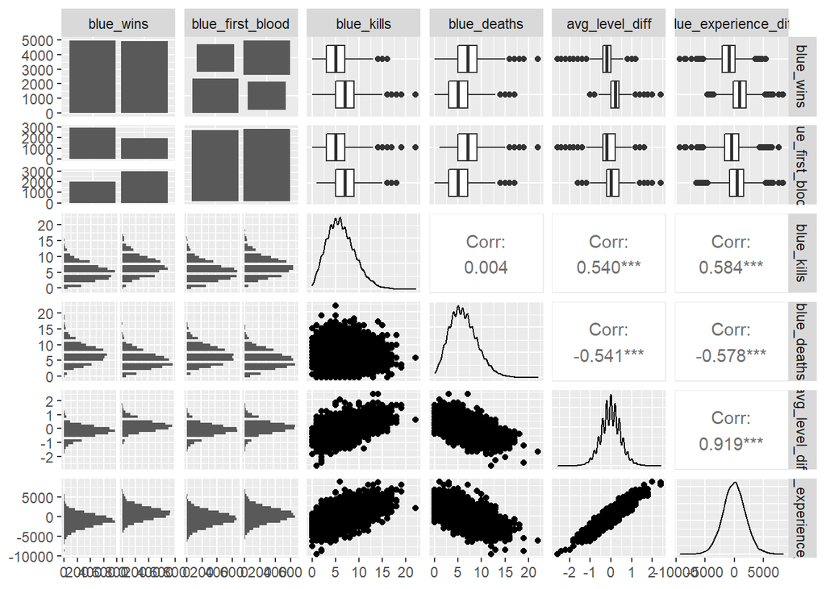

```r
# Correlations

Corr_clean_lol_data <- clean_lol_data %>%
  select(blue_wins, blue_first_blood, blue_kills, blue_deaths, avg_level_diff, blue_experience_diff)
Corr <- Corr_clean_lol_data %>%
  GGally::ggpairs()
Corr
```

```r
# Regression

# Starting with a simple linear regression
regression_clean_lol_data1 <- glm(blue_wins ~ blue_first_blood, data=clean_lol_data, family = "binomial")
summary(regression_clean_lol_data1)
```

```
##
## Call:
## glm(formula = blue_wins ~ blue_first_blood, family = "binomial",
##     data = clean_lol_data)
##
## Deviance Residuals:
##    Min      1Q  Median      3Q     Max
## -1.352  -1.006  -1.006   1.012   1.359
##
## Coefficients:
##                   Estimate Std. Error z value Pr(>|z|)
## (Intercept)       -0.41723    0.02922  -14.28   <2e-16 ***
## blue_first_blood1  0.81836    0.04109   19.91   <2e-16 ***
## ---
## Signif. codes:  0 '***' 0.001 '**' 0.01 '*' 0.05 '.' 0.1 ' ' 1
##
## (Dispersion parameter for binomial family taken to be 1)
##
##     Null deviance: 13695  on 9878  degrees of freedom
## Residual deviance: 13290  on 9877  degrees of freedom
## AIC: 13294
##
## Number of Fisher Scoring iterations: 4
```

```r
# Multiple linear regression

regression_clean_lol_data2 <- glm(blue_wins ~ blue_first_blood + blue_kills + avg_level_diff + blue_experience_diff, data=clean_lol_data, family = "binomial")
summary(regression_clean_lol_data2)
```

```
##
## Call:
## glm(formula = blue_wins ~ blue_first_blood + blue_kills + avg_level_diff +
##     blue_experience_diff, family = "binomial", data = clean_lol_data)
##
## Deviance Residuals:
##     Min       1Q   Median       3Q      Max
## -2.8365  -0.9098  -0.1659   0.9164   2.5411
##
## Coefficients:
##                        Estimate Std. Error z value Pr(>|z|)
## (Intercept)          -0.5160287  0.0649457  -7.946 1.93e-15 ***
## blue_first_blood1     0.4048163  0.0476668   8.493  < 2e-16 ***
## blue_kills            0.0543067  0.0097748   5.556 2.76e-08 ***
## avg_level_diff        0.1429404  0.1248252   1.145    0.252
## blue_experience_diff  0.0005946  0.0000332  17.912  < 2e-16 ***
## ---
## Signif. codes:  0 '***' 0.001 '**' 0.01 '*' 0.05 '.' 0.1 ' ' 1
##
## (Dispersion parameter for binomial family taken to be 1)
##
##     Null deviance: 13695  on 9878  degrees of freedom
## Residual deviance: 10821  on 9874  degrees of freedom
## AIC: 10831
##
## Number of Fisher Scoring iterations: 4
```

```r
# Logistic Regression
regression_clean_lol_data3 <- glm(blue_wins ~ blue_first_blood + blue_kills + avg_level_diff + blue_experience_diff, data=clean_lol_data, family = "binomial")
summary(regression_clean_lol_data3)
```

```
##
## Call:
## glm(formula = blue_wins ~ blue_first_blood + blue_kills + avg_level_diff +
##     blue_experience_diff, family = "binomial", data = clean_lol_data)
##
## Deviance Residuals:
##     Min       1Q   Median       3Q      Max
## -2.8365  -0.9098  -0.1659   0.9164   2.5411
##
## Coefficients:
##                        Estimate Std. Error z value Pr(>|z|)
## (Intercept)          -0.5160287  0.0649457  -7.946 1.93e-15 ***
## blue_first_blood1     0.4048163  0.0476668   8.493  < 2e-16 ***
## blue_kills            0.0543067  0.0097748   5.556 2.76e-08 ***
## avg_level_diff        0.1429404  0.1248252   1.145    0.252
## blue_experience_diff  0.0005946  0.0000332  17.912  < 2e-16 ***
## ---
## Signif. codes:  0 '***' 0.001 '**' 0.01 '*' 0.05 '.' 0.1 ' ' 1
##
## (Dispersion parameter for binomial family taken to be 1)
##
##     Null deviance: 13695  on 9878  degrees of freedom
## Residual deviance: 10821  on 9874  degrees of freedom
## AIC: 10831
##
## Number of Fisher Scoring iterations: 4
```

```r
# Investigating collinearity
exp_level_differential <- lm(avg_level_diff ~ blue_experience_diff, data =clean_lol_data)
summary(exp_level_differential)
```

```
##
## Call:
## lm(formula = avg_level_diff ~ blue_experience_diff, data = clean_lol_data)
##
## Residuals:
##      Min       1Q   Median       3Q      Max
## -0.68458 -0.12803 -0.00116  0.13226  0.68194
##
## Coefficients:
##                        Estimate Std. Error t value Pr(>|t|)
## (Intercept)          -1.614e-03  1.896e-03  -0.851    0.395
## blue_experience_diff  2.290e-04  9.874e-07 231.919   <2e-16 ***
## ---
## Signif. codes:  0 '***' 0.001 '**' 0.01 '*' 0.05 '.' 0.1 ' ' 1
##
## Residual standard error: 0.1885 on 9877 degrees of freedom
## Multiple R-squared:  0.8449, Adjusted R-squared:  0.8448
## F-statistic: 5.379e+04 on 1 and 9877 DF,  p-value: < 2.2e-16
```

```r
# Logistic Regression
regression_clean_lol_data4 <- glm(blue_wins ~ blue_first_blood + blue_kills + blue_experience_diff, data=clean_lol_data, family = "binomial")
summary(regression_clean_lol_data4)
```

```
##
## Call:
## glm(formula = blue_wins ~ blue_first_blood + blue_kills + blue_experience_diff,
##     family = "binomial", data = clean_lol_data)
##
## Deviance Residuals:
##     Min       1Q   Median       3Q      Max
## -2.8371  -0.9107  -0.1688   0.9150   2.5434
##
## Coefficients:
##                        Estimate Std. Error z value Pr(>|z|)
## (Intercept)          -5.180e-01  6.492e-02  -7.980 1.47e-15 ***
## blue_first_blood1     4.061e-01  4.765e-02   8.523  < 2e-16 ***
## blue_kills            5.450e-02  9.773e-03   5.576 2.46e-08 ***
## blue_experience_diff  6.266e-04  1.806e-05  34.696  < 2e-16 ***
## ---
## Signif. codes:  0 '***' 0.001 '**' 0.01 '*' 0.05 '.' 0.1 ' ' 1
##
## (Dispersion parameter for binomial family taken to be 1)
##
##     Null deviance: 13695  on 9878  degrees of freedom
## Residual deviance: 10822  on 9875  degrees of freedom
## AIC: 10830
##
## Number of Fisher Scoring iterations: 4
```